# Lab04

- Show All Code
- Hide All Code
- View Source

Author

Marc Caramoan

Published

August 19, 2024

```r
library(tidyverse)
library(ggplot2)
library(mosaic)
```

## 1 3.1 Personality Type

```r
counts = c(41, 52, 46, 61, 58, 72, 75, 63, 80, 65)
c_mat = matrix(counts, nrow = 2, byrow = TRUE)
colnames(c_mat) = c("Open", "Conscientious", "Extrovert", "Agreeable", "Neurotic")
rownames(c_mat) = c("Business", "Social Science")
c_mat
```

```
               Open Conscientious Extrovert Agreeable Neurotic
Business         41            52        46        61       58
Social Science   72            75        63        80       65
```

Here we want to run a test of homogeneity. We want to make a table of expected cell counts which is equal to row total * column total / total entries.

```r
chisq.test(c_mat, correct = FALSE)
```

```
    Pearson's Chi-squared test

data:  c_mat
X-squared = 3.006, df = 4, p-value = 0.5568
```

we want to check if expected values in our cells are greater than or equal to 5 using the expected property.

```r
chisqtest = chisq.test(c_mat)
chisqtest$expected
```

```
                   Open Conscientious Extrovert Agreeable Neurotic
Business       47.55954      53.45188  45.87602  59.34421 51.76835
Social Science 65.44046      73.54812  63.12398  81.65579 71.23165
```

Here we have a p-value of 0.56, meaning that we do not have sufficient evidence to reject the null hypothesis, which is that the distribution of personality types across business and social science students are equal.

```r
df = data.frame(counts = counts,
                major = c(rep("Business", 5), rep("Social Science", 5)),
                personality = rep(colnames(c_mat), 2))
df
```

| counts | major | personality |
| --- | --- | --- |
| 41 | Business | Open |
| 52 | Business | Conscientious |
| 46 | Business | Extrovert |
| 61 | Business | Agreeable |
| 58 | Business | Neurotic |
| 72 | Social Science | Open |
| 75 | Social Science | Conscientious |
| 63 | Social Science | Extrovert |
| 80 | Social Science | Agreeable |
| 65 | Social Science | Neurotic |

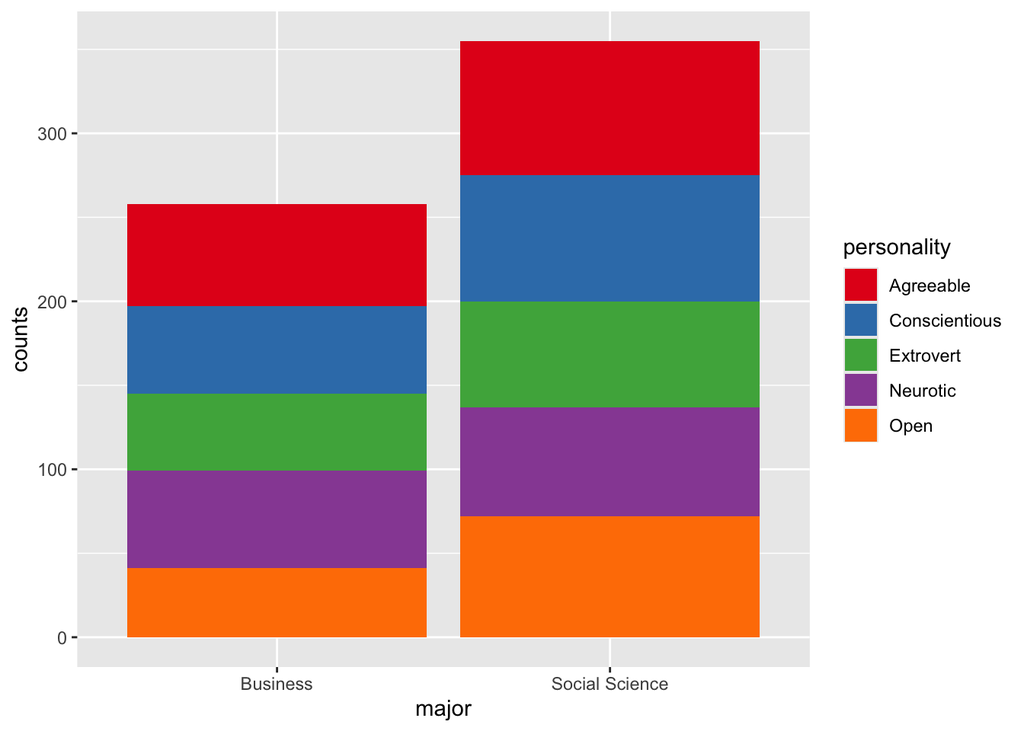

```r
df |> ggplot() +
  aes(x = major, y = counts, fill = personality) +
  geom_col() +
  scale_fill_brewer(palette = "Set1")
```

to get proportion column, use position = fill

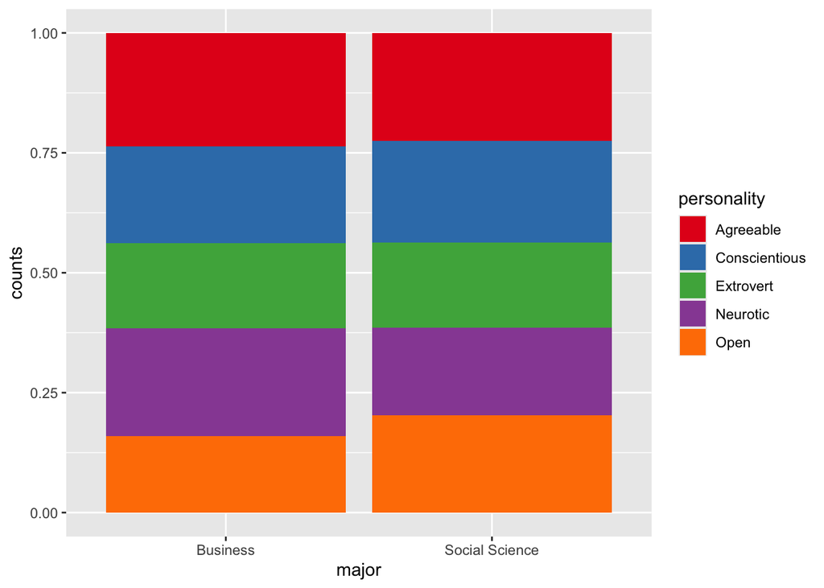

```r
df |> ggplot() +
  aes(x = major, y = counts, fill = personality) +
  geom_col(position = "fill") +
  scale_fill_brewer(palette = "Set1")
```

so we can see here it looks pretty homogenous.

## 2 3.2 Shocking

```r
shocking = c(12, 4, 5, 9)
s_mat = matrix(shocking, nrow = 2)
colnames(s_mat) = c("Wait together", "Wait alone")
rownames(s_mat) = c("High anxiety", "Low anxiety")
s_mat
```

```
             Wait together Wait alone
High anxiety            12          5
Low anxiety              4          9
```

### 2.1 Fisher’s Exact Test

```r
fisher.test(s_mat)
```

```
    Fisher's Exact Test for Count Data

data:  s_mat
p-value = 0.06336
alternative hypothesis: true odds ratio is not equal to 1
95 percent confidence interval:
  0.8958353 35.0773293
sample estimates:
odds ratio
  5.069118
```

We do not reject the null hypothesis as $p > 0.05$. There is insufficient evidence to conclude that there is a relationship between anxiety level and the decision to wait together.

Now we want to do it with continuity correction and without

```r
chisq.test(s_mat, correct = TRUE)
```

```
    Pearson's Chi-squared test with Yates' continuity correction

data:  s_mat
X-squared = 3.2294, df = 1, p-value = 0.07233
```

Now we want to do it with correct:

```r
chisq.test(s_mat, correct = FALSE)
```

```
    Pearson's Chi-squared test

data:  s_mat
X-squared = 4.693, df = 1, p-value = 0.03029
```

```r
chisqtest = chisq.test(s_mat)
chisqtest$expected
```

```
             Wait together Wait alone
High anxiety      9.066667   7.933333
Low anxiety       6.933333   6.066667
```

```r
chisq.test(s_mat, simulate.p.value = T, B = 20000)
```

```
    Pearson's Chi-squared test with simulated p-value (based on 20000
    replicates)

data:  s_mat
X-squared = 4.693, df = NA, p-value = 0.0611
```

we can calculate the odds ratio

```r
mosaic::oddsRatio(s_mat[c(2,1),], verbose = T)
```

```
Odds Ratio

Proportions
       Prop. 1:  0.3077
       Prop. 2:  0.7059
     Rel. Risk:  2.294

Odds
        Odds 1:  0.4444
        Odds 2:  2.4
    Odds Ratio:  5.4

95 percent confidence interval:
     0.96 < RR < 5.483
     1.12 < OR < 26.04
NULL
```

```
[1] 5.4
```

Given a patient was told “high”, the odds of staying together are 5.4 times higher than those who were told “low”.

## 3 Asbestos

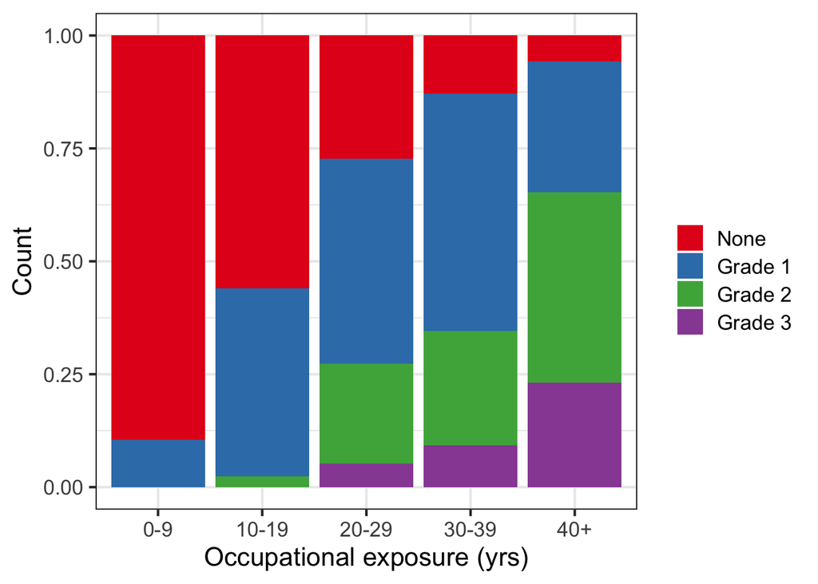

```r
asbestos = matrix(c(310, 212, 21, 25, 7, 36, 158, 35, 102,
                    35, 0, 9, 17, 49, 51, 0, 0, 4, 18, 28), nrow = 5)
colnames(asbestos) = c("None", "Grade 1", "Grade 2", "Grade 3")
rownames(asbestos) = c("0-9", "10-19", "20-29", "30-39", "40+")
y = asbestos |> as.data.frame() |>
  tibble::rownames_to_column(var = "years") |>
  tidyr::gather(key = grade, value = count, -years)
y$grade = factor(y$grade, levels = c("None", "Grade 1", "Grade 2", "Grade 3"), ordered = TRUE)
ggplot(y, aes(x = years, y = count, fill = grade)) +
  geom_bar(stat = "identity", position = "fill") +
  theme_bw(base_size = 16) +
  scale_fill_brewer(palette = "Set1") +
  labs(fill = "", y = "Count", x = "Occupational exposure (yrs)")
```

```r
chisq.test(asbestos)
```

```
    Pearson's Chi-squared test

data:  asbestos
X-squared = 648.81, df = 12, p-value < 2.2e-16
```

```r
set.seed(123)
B = 10000
row_totals = rowSums(asbestos)
col_totals = colSums(asbestos)
x = r2dtable(n = B,
             r = row_totals,
             c = col_totals)
x[[1]]
```

```
     [,1] [,2] [,3] [,4]
[1,]  181  105   45   15
[2,]  205  112   43   19
[3,]   40   31    5    1
[4,]   95   76   15    8
[5,]   54   42   18    7
```

```r
chisq.test(x[[1]])
```

```
    Pearson's Chi-squared test

data:  x[[1]]
X-squared = 16.141, df = 12, p-value = 0.1848
```

Here, the observed test statistic for the first random sample is 16.141, and p-value is 0.1848

now for each of the 10000 randomly generated contingency tables, we want to record the t stat.

```r
sim_stats = c()
for (i in 1:B) { # loop over B iterations and each time, save the t stat
  stat = suppressWarnings(chisq.test(x[[i]])$statistic)
  sim_stats = c(sim_stats, stat)
}
head(sim_stats)
```

```
X-squared X-squared X-squared X-squared X-squared X-squared
16.141379 19.203058 14.540454  2.327157  8.774264 11.687903
```

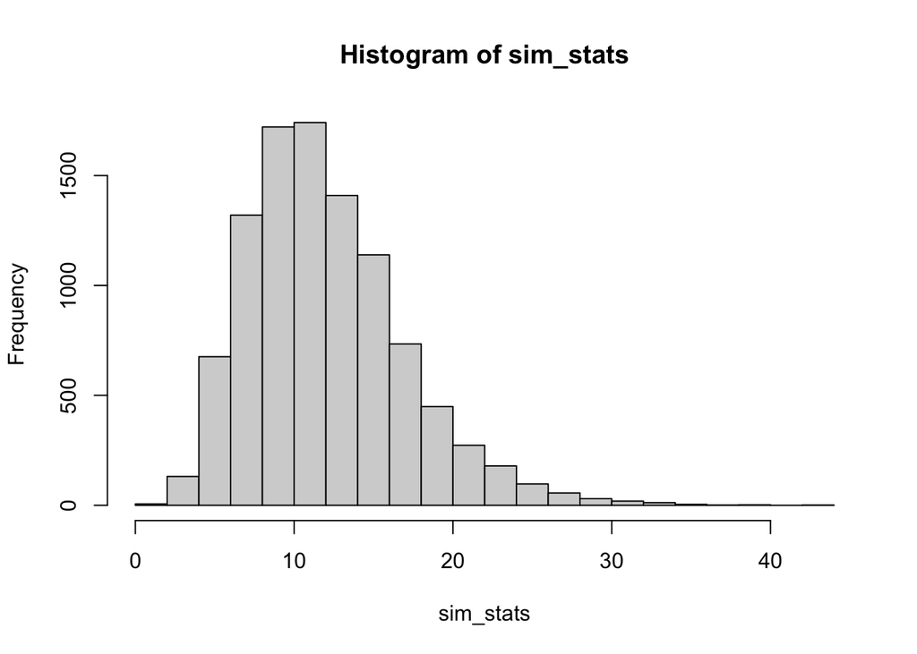

```r
hist(sim_stats)
```

what prop of time did we observe a test stat as or more extreme than what we observed?

```r
t0 = chisq.test(asbestos)$statisti
t0
```

```
X-squared
 648.8115
```

```r
mean(sim_stats >= t0)
```

```
[1] 0
```